# FARS vignette

Alfonso Delgado-Bonal

19 de marzo de 2017

# About this package

This package has been created for reading, summarise and plot data from the US National Highway Traffic Safety Administration’s [Fatality Analysis Reporting System.](https://www.nhtsa.gov/research-data/fatality-analysis-reporting-system-fars)

This system is a nationwide census providing the American public yearly data regarding fatal injuries suffered in motor vehicle traffic crashes.

## Data

You can download the data used in this package from [here.](https://www.nhtsa.gov/research-data/fatality-analysis-reporting-system-fars)

## Reading data: `make_filename`, `fars_read` and `fars_read_years` functions

The raw data from FARS is a annual set of data in CSV format, containing several columns which are not necessary for this package. Using the functions from this package, a tidy dataset containing only the required information is obtained. See individual help for each function for more information.

The only required information from the user is the year or years for the analysis. Some examples of this functions are:

```r
setwd("../R")
source("fars_functions.R")
library(maps)
library(graphics)
library(dplyr)
make_filename(2014)
```

```
## [1] "../inst/extdata/accident_2014.csv.bz2"
```

```r
fars_read(make_filename(2013))
```

```
## # A tibble: 30,202 × 50
##    STATE ST_CASE VE_TOTAL VE_FORMS PVH_INVL  PEDS PERNOTMVIT PERMVIT
##    <int>   <int>    <int>    <int>    <int> <int>      <int>   <int>
## 1      1   10001        1        1        0     0          0       8
## 2      1   10002        2        2        0     0          0       2
## 3      1   10003        1        1        0     0          0       1
## 4      1   10004        1        1        0     0          0       3
## 5      1   10005        2        2        0     0          0       3
## 6      1   10006        2        2        0     0          0       3
## 7      1   10007        1        1        0     0          0       1
## 8      1   10008        2        2        0     0          0       2
## 9      1   10009        1        1        0     0          0       1
## 10     1   10010        2        2        0     0          0       4
## # ... with 30,192 more rows, and 42 more variables: PERSONS <int>,
## #   COUNTY <int>, CITY <int>, DAY <int>, MONTH <int>, YEAR <int>,
## #   DAY_WEEK <int>, HOUR <int>, MINUTE <int>, NHS <int>, ROAD_FNC <int>,
## #   ROUTE <int>, TWAY_ID <chr>, TWAY_ID2 <chr>, MILEPT <int>,
## #   LATITUDE <dbl>, LONGITUD <dbl>, SP_JUR <int>, HARM_EV <int>,
## #   MAN_COLL <int>, RELJCT1 <int>, RELJCT2 <int>, TYP_INT <int>,
## #   WRK_ZONE <int>, REL_ROAD <int>, LGT_COND <int>, WEATHER1 <int>,
## #   WEATHER2 <int>, WEATHER <int>, SCH_BUS <int>, RAIL <chr>,
## #   NOT_HOUR <int>, NOT_MIN <int>, ARR_HOUR <int>, ARR_MIN <int>,
## #   HOSP_HR <int>, HOSP_MN <int>, CF1 <int>, CF2 <int>, CF3 <int>,
## #   FATALS <int>, DRUNK_DR <int>
```

```r
fars_read_years(c(2013, 2014))
```

```
## [1] "../inst/extdata/accident_2013.csv.bz2"
## [1] "../inst/extdata/accident_2014.csv.bz2"
```

```
## [[1]]
## # A tibble: 30,202 × 2
##    MONTH  year
##    <int> <dbl>
## 1      1  2013
## 2      1  2013
## 3      1  2013
## 4      1  2013
## 5      1  2013
## 6      1  2013
## 7      1  2013
## 8      1  2013
## 9      1  2013
## 10     1  2013
## # ... with 30,192 more rows
##
## [[2]]
## # A tibble: 30,056 × 2
##    MONTH  year
##    <int> <dbl>
## 1      1  2014
## 2      1  2014
## 3      1  2014
## 4      1  2014
## 5      1  2014
## 6      1  2014
## 7      1  2014
## 8      1  2014
## 9      1  2014
## 10     1  2014
## # ... with 30,046 more rows
```

## Summarizing data: the `fars_summarize_years` function

The information can be summarized for the given years in a simple way using the function `fars_summarize_years`:

```r
fars_summarize_years(c(2013,2014,2015))
```

```
## [1] "../inst/extdata/accident_2013.csv.bz2"
## [1] "../inst/extdata/accident_2014.csv.bz2"
## [1] "../inst/extdata/accident_2015.csv.bz2"
```

```
## # A tibble: 12 × 4
##    MONTH `2013` `2014` `2015`
## *  <int>  <int>  <int>  <int>
## 1      1   2230   2168   2368
## 2      2   1952   1893   1968
## 3      3   2356   2245   2385
## 4      4   2300   2308   2430
## 5      5   2532   2596   2847
## 6      6   2692   2583   2765
## 7      7   2660   2696   2998
## 8      8   2899   2800   3016
## 9      9   2741   2618   2865
## 10    10   2768   2831   3019
## 11    11   2615   2714   2724
## 12    12   2457   2604   2781
```

## Plotting data: the `fars_map_state` function

Finally, you are able to plot the results to take a look on the distribution. Here is an example for the state number 1 and the year 2014. The user only have to provide the state number as first argument and the year as second. Read the help page of the function if more information is required.

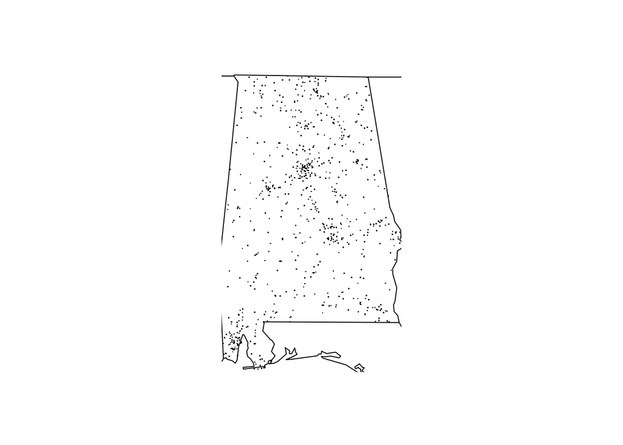

```r
fars_map_state(1,2014)
```